# notebook_Dr. Semmelweis and the Discovery of Handwashing

Pierre-Etienne TOULEMONDE

2022-12-08

# 1 The Discovery of Handwashing

Tags: Data manipulation, Data visualization, Probability & statistics, Importing & cleaning data, Case studies

Principal packages: tidyverse, patchwork.

In 1847, Dr. Semmelweis instated a policy where doctors had to use a chlorine solution to wash their hands between performing autopsies and seeing patients. The maternal mortality rate drastically decreased as seen in the plot below. Sadly, germ theory (the idea that there are particles that cause disease) was not widely accepted at the time, so his hypothesis was rejected by most doctors.

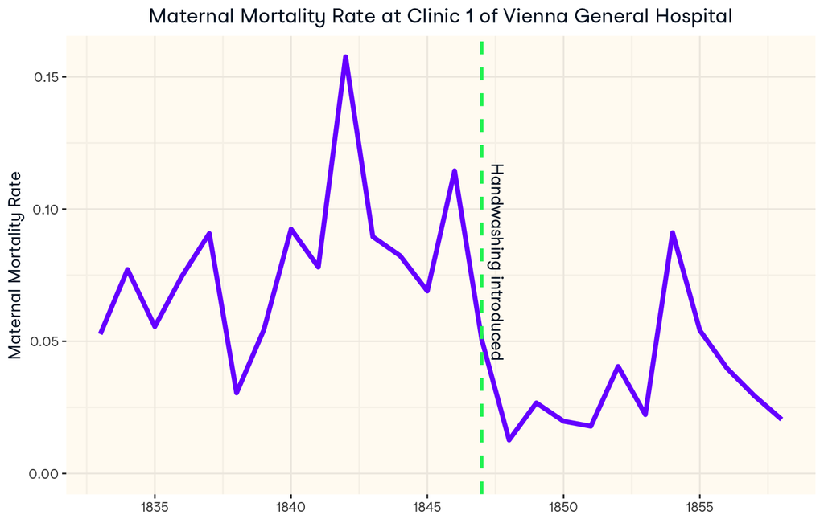

The two datasets you will use are from Dr. Semmelweis’s original 1859 publication<sup>1</sup>. Here are the details:

**datasets/clinic_data.csv**

This contains yearly clinic-level data on births and maternal deaths in each of the two maternity clinics at Vienna General Hospital.

- **`year`:** each year from 1833 to 1858
- **`births`:** total number of births in the clinic
- **`deaths`:** number of maternal deaths in the clinic
- **`clinic`:** clinic (either `clinic_1` or `clinic_2`). Doctors and midwives worked in Clinic 1, while only midwives worked in Clinic 2.

**datasets/hospital_data.csv**

This contains yearly hospital-level data on births and maternal deaths.

- **`year`:** each year from 1784 to 1848
- **`births`:** total number of births at the hospital
- **`deaths`:** number of maternal deaths at the hospital
- **`hospital`:** hospital (either `Vienna` or `Dublin`). At the Vienna General Hospital where Dr. Semmelweis worked, doctors began performing pathological autopsies in 1823. At the Dublin Rotunda Hospital, doctors did not perform pathological autopsies at all.

<sup>1</sup>[Ignaz Semmelweis: The etiology, concept, and prophylaxis of childbed fever.](http://graphics8.nytimes.com/images/blogs/freakonomics/pdf/the%20etiology,%20concept%20and%20prophylaxis%20of%20childbed%20fever.pdf)

From there, the aim is to explore and manipulate existing data to answer these questions:

1. What were the death rates for each year in the both datasets?
2. In each clinic, what was the average death rate for the years before handwashing was introduced in 1847?
3. What were the average death rates in the Vienna General Hospital both before and after pathological autopsies were introduced in 1823?

## 1.1 Data Description

```r
# ---------- 0. Package importation ----------
# install.packages("librarian")
librarian::shelf(tidyverse,
                 patchwork,
                 quiet = TRUE)

# ---------- 1. Data Importation ----------
clinic_data <- read.csv("datasets/clinic_data.csv")
hospital_data <- read.csv("datasets/hospital_data.csv")
```

### 1.1.1 General informations

```r
# ---------- 2. Data exploration ----------
print(data.frame(
  Variables = c("Number of lines",
               "Nombre de columns",
               "Nombre de continuous columns",
               "Nombre de discretous variables",
               "Memory allocation"),
  Clinic_data = c(nrow(clinic_data),
                  ncol(clinic_data),
                  length(select_if(clinic_data,is.numeric)),
                  length(select(clinic_data, -names(select_if(clinic_data, is.numeric) ) ) ),
                  paste(as.character(round(object.size(clinic_data)/1024), 2), "kb") ),
  Hospital_data = c(nrow(hospital_data),
                  ncol(hospital_data),
                  length(select_if(hospital_data,is.numeric)),
                  length(select(hospital_data, -names(select_if(hospital_data, is.numeric) ) ) ),
                  paste(as.character(round(object.size(hospital_data)/1024), 2), "kb") ) ) )
```

```
##                        Variables Clinic_data Hospital_data
## 1                Number of lines          52           130
## 2              Nombre de columns           4             4
## 3   Nombre de continuous columns           3             3
## 4 Nombre de discretous variables           1             1
## 5              Memory allocation        2 kb          4 kb
```

### 1.1.2 Clinic dataset

The ten first row of clinic_dataset are :

```r
head(clinic_data, n = 10)
```

```
##    year births deaths   clinic
## 1  1833   3737    197 clinic_1
## 2  1834   2657    205 clinic_1
## 3  1835   2573    143 clinic_1
## 4  1836   2677    200 clinic_1
## 5  1837   2765    251 clinic_1
## 6  1838   2987     91 clinic_1
## 7  1839   2781    151 clinic_1
## 8  1840   2889    267 clinic_1
## 9  1841   3036    237 clinic_1
## 10 1842   3287    518 clinic_1
```

About missing data :

```r
print(data.frame(variables = names(clinic_data),
                 n_NA = apply(clinic_data, 2, function(.x) {sum(is.na(.x) )} ),
                 percent_NA = apply(clinic_data, 2,
                                    function(.x) { paste(round(sum(is.na(.x) ) /
                                                                 nrow(clinic_data) * 100, 2) , "%") } ) ) )
```

```
##        variables n_NA percent_NA
## year        year    0        0 %
## births    births    0        0 %
## deaths    deaths    0        0 %
## clinic    clinic    0        0 %
```

#### 1.1.2.1 Graphic description

- `births`:

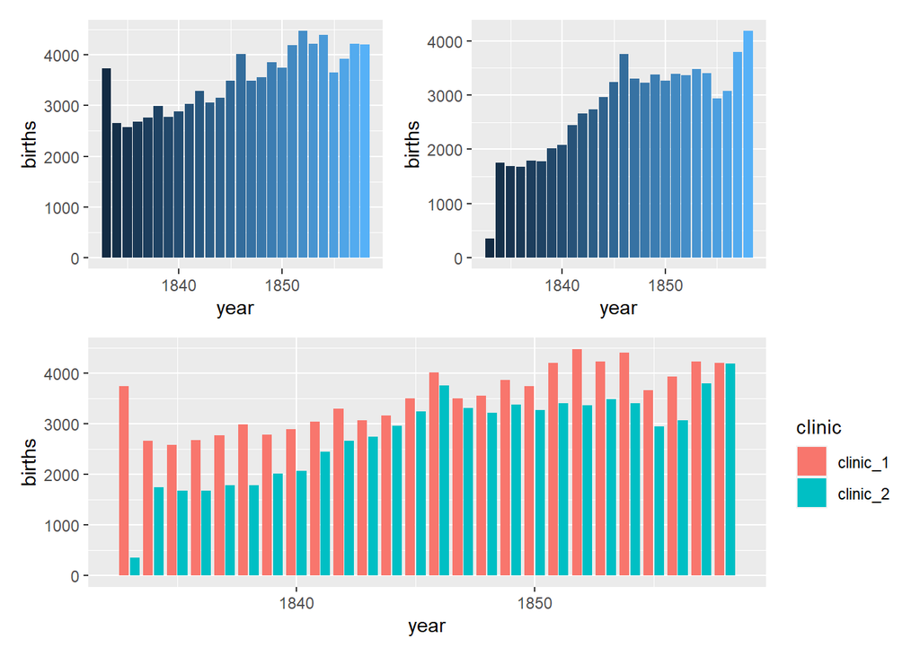

```r
p1 <- clinic_data %>%
        filter(clinic == "clinic_1") %>%
        ggplot(aes(x=year, y = births, fill = year)) +
          geom_col() +
          theme(legend.position = "none")
p2 <- clinic_data %>%
        filter(clinic == "clinic_2") %>%
        ggplot(aes(x=year, y = births, fill = year)) +
          geom_col() +
          theme(legend.position = "none")
q <- ggplot(clinic_data, aes(x=year, y = births, fill = clinic)) +
  geom_col(position = position_dodge2())
(p1 + p2) / q # Display of graphics
```

- `deaths`:

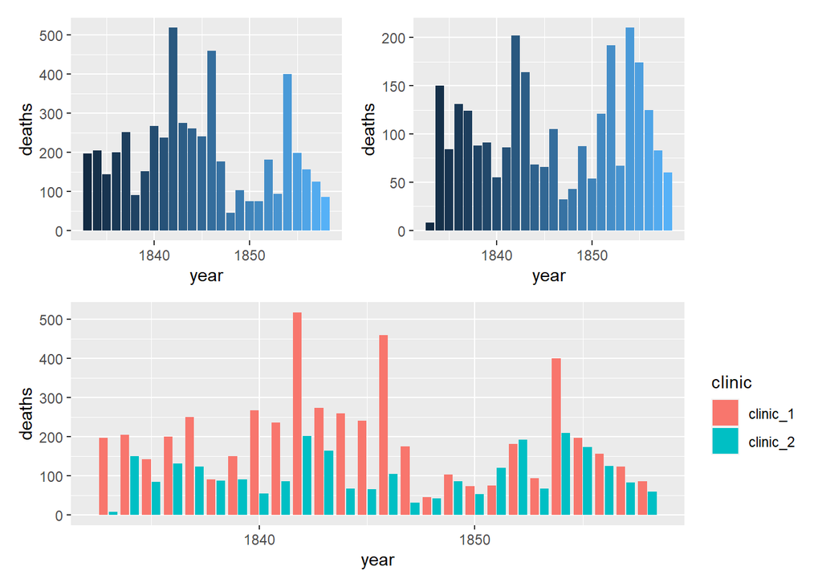

```r
p1 <- clinic_data %>%
        filter(clinic == "clinic_1") %>%
        ggplot(aes(x=year, y = deaths, fill = year)) +
          geom_col() +
          theme(legend.position = "none")
p2 <- clinic_data %>%
        filter(clinic == "clinic_2") %>%
        ggplot(aes(x=year, y = deaths, fill = year)) +
          geom_col() +
          theme(legend.position = "none")
q <- ggplot(clinic_data, aes(x=year, y = deaths, fill = clinic)) +
  geom_col(position = position_dodge2())
(p1 + p2) / q # Display of graphics
```

### 1.1.3 Hospital dataset

The ten first row of hospital_dataset are :

```r
head(hospital_data, n = 10)
```

```
##    year births deaths hospital
## 1  1784   1261     11   Dublin
## 2  1785   1292      8   Dublin
## 3  1786   1351      8   Dublin
## 4  1787   1347     10   Dublin
## 5  1788   1469     23   Dublin
## 6  1789   1435     25   Dublin
## 7  1790   1546     12   Dublin
## 8  1791   1602     25   Dublin
## 9  1792   1631     10   Dublin
## 10 1793   1747     19   Dublin
```

```r
print(data.frame(variables = names(hospital_data),
                 n_NA = apply(hospital_data, 2, function(.x) {sum(is.na(.x) )} ),
                 percent_NA = apply(hospital_data, 2, function(.x) { paste(round(sum(is.na(.x) ) / nrow(hospital_data) * 100, 2) , "%") } ) ) )
```

```
##          variables n_NA percent_NA
## year          year    0        0 %
## births      births    0        0 %
## deaths      deaths    0        0 %
## hospital  hospital    0        0 %
```

#### 1.1.3.1 Graphic description

- `births`:

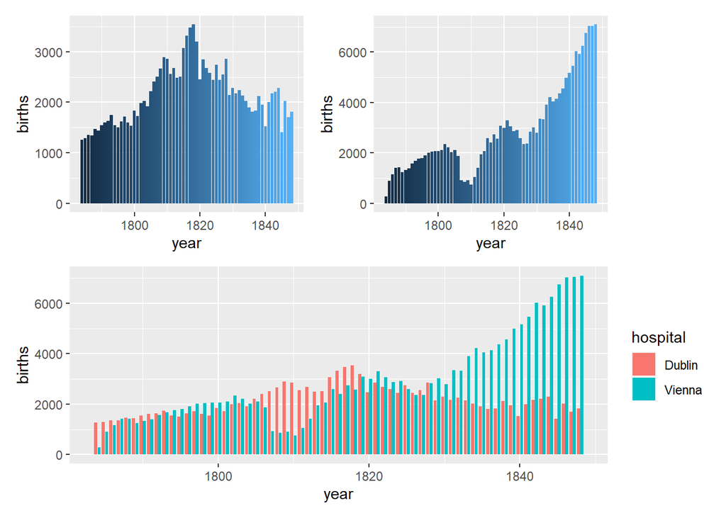

```r
p1 <- hospital_data %>%
        filter(hospital == "Dublin") %>%
        ggplot(aes(x=year, y = births, fill = year)) +
          geom_col() +
          theme(legend.position = "none")
p2 <- hospital_data %>%
        filter(hospital == "Vienna") %>%
        ggplot(aes(x=year, y = births, fill = year)) +
          geom_col() +
          theme(legend.position = "none")
q <- ggplot(hospital_data, aes(x=year, y = births, fill = hospital)) +
  geom_col(position = position_dodge2())
(p1 + p2) / q # Display of graphics
```

- `deaths`:

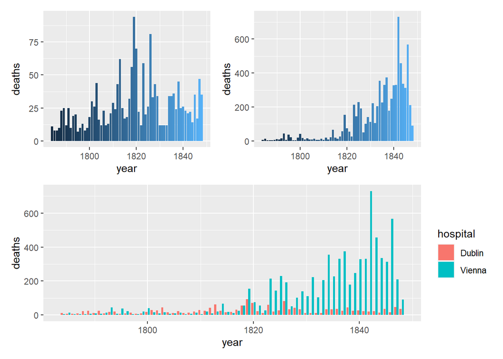

```r
p1 <- hospital_data %>%
        filter(hospital == "Dublin") %>%
        ggplot(aes(x=year, y = deaths, fill = year)) +
          geom_col() +
          theme(legend.position = "none")
p2 <- hospital_data %>%
        filter(hospital == "Vienna") %>%
        ggplot(aes(x=year, y = deaths, fill = year)) +
          geom_col() +
          theme(legend.position = "none")
q <- ggplot(hospital_data, aes(x=year, y = deaths, fill = hospital)) +
  geom_col(position = position_dodge2())
(p1 + p2) / q # Display of graphics
```

## 1.2 Questions

As a reminder, questions are :

1. What were the death rates for each year in the both datasets?
2. In each clinic, what was the average death rate for the years before handwashing was introduced in 1847?
3. What were the average death rates in the Vienna General Hospital both before and after pathological autopsies were introduced in 1823?

### 1.2.1 Q1. What were the death rates for each year in the both datasets?

The top 15 mortality rates, over the period and the 2 clinics, were :

```r
clinic_data %>%
  mutate(death_rate = deaths/births) %>%
  select(-births, -deaths) %>%
  top_n(15, death_rate)
```

```
##    year   clinic death_rate
## 1  1834 clinic_1 0.07715469
## 2  1836 clinic_1 0.07471050
## 3  1837 clinic_1 0.09077758
## 4  1840 clinic_1 0.09241952
## 5  1841 clinic_1 0.07806324
## 6  1842 clinic_1 0.15759051
## 7  1843 clinic_1 0.08954248
## 8  1844 clinic_1 0.08235667
## 9  1845 clinic_1 0.06901489
## 10 1846 clinic_1 0.11446384
## 11 1854 clinic_1 0.09105395
## 12 1834 clinic_2 0.08600917
## 13 1836 clinic_2 0.07844311
## 14 1837 clinic_2 0.06950673
## 15 1842 clinic_2 0.07596841
```

The top 15 mortality rates, over the period and the 2 hospitals, were :

```r
hospital_data %>%
  mutate(death_rate = deaths/births) %>%
  select(-births, -deaths) %>%
  top_n(15, death_rate)
```

```
##    year hospital death_rate
## 1  1823   Vienna 0.07451253
## 2  1825   Vienna 0.08828065
## 3  1826   Vienna 0.08139042
## 4  1831   Vienna 0.06620936
## 5  1833   Vienna 0.05246993
## 6  1834   Vienna 0.08416311
## 7  1835   Vienna 0.05618812
## 8  1836   Vienna 0.07987452
## 9  1837   Vienna 0.08595003
## 10 1840   Vienna 0.06349206
## 11 1841   Vienna 0.06050605
## 12 1842   Vienna 0.12118194
## 13 1843   Vienna 0.07727426
## 14 1844   Vienna 0.05381166
## 15 1846   Vienna 0.08068877
```

### 1.2.2 Q2. In each clinic, what was the average death rate for the years before handwashing was introduced in 1847?

```r
rate_by_clinic_pre_handwashing <- clinic_data %>%
        mutate(death_rate = deaths/births) %>%
        filter (year < 1847) %>%
        group_by(clinic) %>%
        summarise(avg_rate = mean(death_rate))
print( rate_by_clinic_pre_handwashing )
```

```
## # A tibble: 2 × 2
##   clinic   avg_rate
##   <chr>       <dbl>
## 1 clinic_1   0.0799
## 2 clinic_2   0.0479
```

The average death rate of `clinic_1` is 0.0799393 . The average death rate of `clinic_2` is 0.0478738 .

### 1.2.3 Q3. What were the average death rates in the Vienna General Hospital both before and after pathological autopsies were introduced in 1823?

```r
rate_by_autopsies_introduced <- hospital_data %>%
        mutate(death_rate = deaths/births) %>%
        filter(hospital=="Vienna") %>%
        mutate(autopsies_introduced = year >= 1823) %>%
        group_by(autopsies_introduced) %>%
        summarise(avg_rate = mean(death_rate))
print( rate_by_autopsies_introduced )
```

```
## # A tibble: 2 × 2
##   autopsies_introduced avg_rate
##   <lgl>                   <dbl>
## 1 FALSE                  0.0117
## 2 TRUE                   0.0588
```

# 2 Session

```r
print( paste0( "System version : ", sessionInfo()$running, ", ", sessionInfo()$platform) )
```

```
## [1] "System version : Windows 10 x64 (build 19045), x86_64-w64-mingw32/x64 (64-bit)"
```

```r
print( paste0( R.version$version.string, " - ", R.version$nickname ) )
```

```
## [1] "R version 4.2.0 (2022-04-22 ucrt) - Vigorous Calisthenics"
```

```r
for (package in c( sessionInfo()$basePkgs, objects(sessionInfo()$otherPkgs) ) ) {
  print( paste0( package, " : ", package, "_", packageVersion(package) ) ) }
```

```
## [1] "stats : stats_4.2.0"
## [1] "graphics : graphics_4.2.0"
## [1] "grDevices : grDevices_4.2.0"
## [1] "utils : utils_4.2.0"
## [1] "datasets : datasets_4.2.0"
## [1] "methods : methods_4.2.0"
## [1] "base : base_4.2.0"
## [1] "dplyr : dplyr_1.0.10"
## [1] "forcats : forcats_0.5.1"
## [1] "ggplot2 : ggplot2_3.3.6"
## [1] "patchwork : patchwork_1.1.1"
## [1] "purrr : purrr_0.3.4"
## [1] "readr : readr_2.1.2"
## [1] "stringr : stringr_1.4.0"
## [1] "tibble : tibble_3.1.7"
## [1] "tidyr : tidyr_1.2.0"
## [1] "tidyverse : tidyverse_1.3.2"
```